# Implementando ICs - Antônio Esteves

Nazareno

## Os dados

```r
set.seed(12345)

lastfm = read_csv(here::here("data/experimento-lastfm.csv"),
                  col_types = cols(.default = col_double(),
                                   user = col_character()))

lastfm = lastfm %>%
  sample_n(300) %>%
  select(news, old, mediana_pop)

glimpse(lastfm)
```

```
## Observations: 300
## Variables: 3
## $ news        <dbl> 28, 35, 13, 24, 14, 17, 13, 21, 34, 55, 10, 33, 10, …
## $ old         <dbl> 61, 194, 70, 96, 130, 67, 106, 123, 76, 78, 76, 116,…
## $ mediana_pop <dbl> 6.105585, 5.376812, 5.713082, 4.564335, 5.782320, 5.…
```

## Proporção de artistas novos e popularidade

Utilizaremos ICs para estimar duas métricas sobre os usuários do LastFM em geral durante um período de 6 meses. Em ambos os casos faremos isso a partir de uma amostra de 300 usuários. As duas métricas são:

# 1 - Qual a proporção de novos artistas em geral escutada por usuários?

```r
mylastfm = lastfm %>%
  mutate(news_prop_artist = (news/(news+old)))

funcao_theta = function(df) {
  df %>%
    pull(news_prop_artist) %>%
    mean()
}

theta = funcao_theta(mylastfm)

set.seed(1212)
amostra = mylastfm %>%
  sample_n(200)

theta_c = funcao_theta(amostra)
```

```r
repeticoes = 4000 # pelo menos 2000, mas mais não faz mal.

um_bootstrap <- function(x){
  news_prop_artist = x %>% pull(news_prop_artist)
  boot_x <- sample(news_prop_artist,           # amostre dos dados
                   size = NROW(news_prop_artist), # tamanho igual ao recebido
                   replace = TRUE) # aqui é o bootstrap
  return(mean(boot_x))
}

set.seed(1212)

reamostragens = tibble(i = 1:repeticoes) %>%
  mutate(theta_c_s = map_dbl(i, ~ um_bootstrap(mylastfm)))

reamostragens
```

| i | theta_c_s |
| --- | --- |
| 1 | 0.2443757 |
| 2 | 0.2453269 |
| 3 | 0.2431166 |
| 4 | 0.2364452 |
| 5 | 0.2524764 |
| 6 | 0.2444356 |
| 7 | 0.2516275 |
| 8 | 0.2577084 |
| 9 | 0.2525730 |
| 10 | 0.2474149 |

[output cut: 3990 more lines]

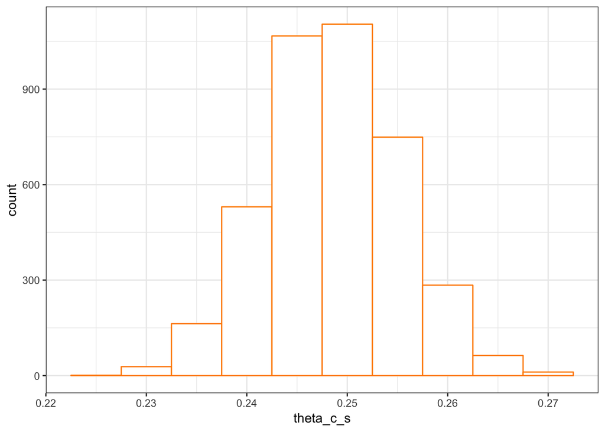

```r
reamostragens %>%
  ggplot(aes(x = theta_c_s)) +
  geom_histogram(binwidth = .005,
                 colour = "darkorange",
                 fill = "white")
```

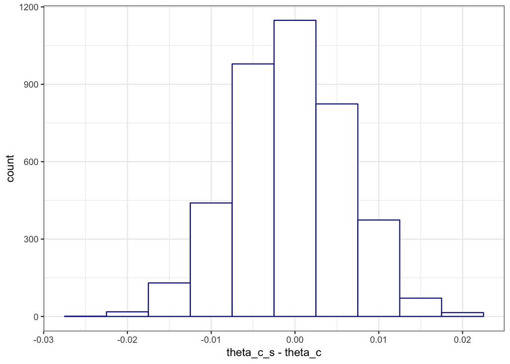

```r
reamostragens %>%
  ggplot(aes(x = theta_c_s - theta_c)) +
  geom_histogram(binwidth = .005,
                 colour = "darkblue",
                 fill = "white")
```

```r
intervalo = reamostragens %>%
  mutate(erro = theta_c_s - theta_c) %>%
  summarise(erro_i = quantile(erro, .025),
            erro_s = quantile(erro, .975))

intervalo
```

| erro_i | erro_s |
| --- | --- |
| -0.01361488 | 0.01205091 |

```r
intervalo = intervalo %>%
  mutate(valor_i = theta_c + erro_i,
         valor_s = theta_c + erro_s)

intervalo
```

| erro_i | erro_s | valor_i | valor_s |
| --- | --- | --- | --- |
| -0.01361488 | 0.01205091 | 0.2354885 | 0.2611543 |

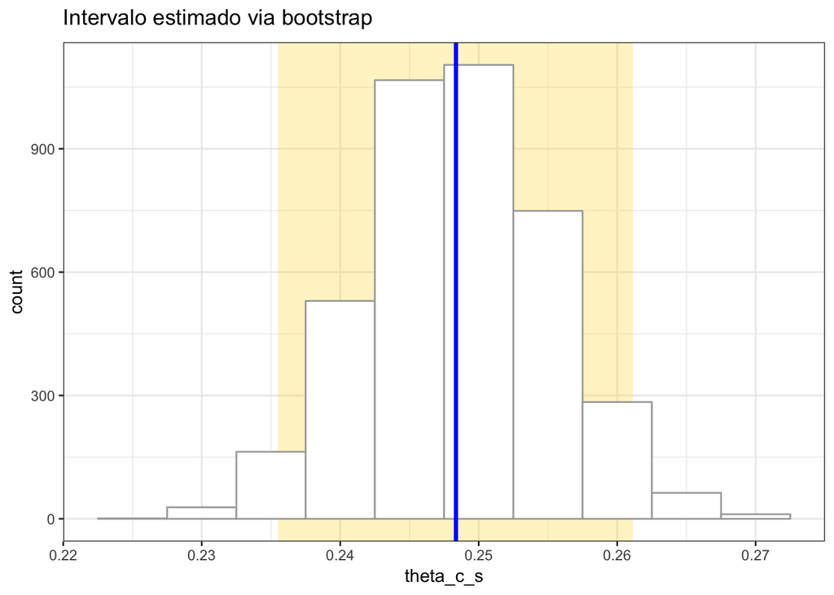

```r
ggplot() +
  geom_rect(
    data = intervalo,
    aes(xmin = valor_i, xmax = valor_s),
    ymin = -Inf,
    ymax = Inf,
    fill = "gold",
    alpha = .25
  ) +
  geom_histogram(
    data = reamostragens,
    aes(theta_c_s),
    binwidth = .005,
    fill = "white",
    colour = "darkgrey"
  ) +
  geom_vline(xintercept = theta,
             color = "blue",
             size = 1.2) +
  labs(title = expression("Intervalo estimado via bootstrap"))
```

# 1.1 - Proporção de novos artistas em geral escutada por usuários (Bootstrap Library)

```r
library(boot)

theta = function(df, i) {
  df %>%
    slice(i) %>%
    pull(news_prop_artist) %>%
    mean()
}

booted <- boot(data = mylastfm,
               statistic = theta,
               R = 2000)


ci = tidy(booted,
          conf.level = .95,
          conf.method = "bca",
          conf.int = TRUE)

glimpse(ci)
```

```
## Observations: 1
## Variables: 5
## $ statistic <dbl> 0.2483568
## $ bias      <dbl> -9.096478e-05
## $ std.error <dbl> 0.006588632
## $ conf.low  <dbl> 0.2355955
## $ conf.high <dbl> 0.2623259
```

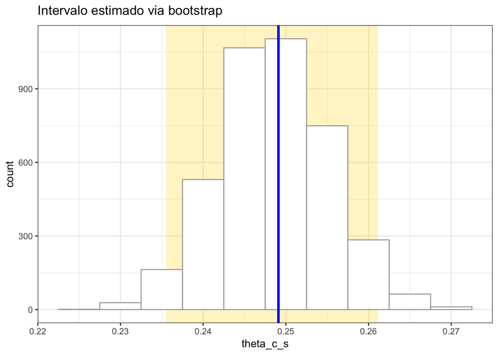

```r
ggplot() +
  geom_rect(
    data = intervalo,
    aes(xmin = valor_i, xmax = valor_s),
    ymin = -Inf,
    ymax = Inf,
    fill = "gold",
    alpha = .25
  ) +
  geom_histogram(
    data = reamostragens,
    aes(theta_c_s),
    binwidth = .005,
    fill = "white",
    colour = "darkgrey"
  ) +
  geom_vline(xintercept = theta_c,
             color = "blue",
             size = 1.2) +
  # geom_vline(xintercept = theta_c, color = "dark green") +
  labs(title = expression("Intervalo estimado via bootstrap"))
```

# 1.1 - Conclusões.

Podemos observar que a média dos novos artistas escutados das amostragens, condiz com a média da população como um todo, com valores no intervalo de 0,23 e 0,26, com 95% de confiança, ou seja, em 95% do tempo isso é válido.

# 2 - Para os usuários que gostam de música muito pop (mediana_pop > 5), qual a correlação entre a popularidade mediana dos artistas escutado e a proporção dos artistas escutados que eram novos.

```r
mylastfm_two = mylastfm%>%
  filter(mediana_pop > 5)

funcao_theta = function(df) {
  with(df, cor(mediana_pop, news_prop_artist,method = "pearson"))
}

theta = funcao_theta(mylastfm_two)

set.seed(1212)
amostra = mylastfm_two %>%
  sample_n(200)

theta_c = funcao_theta(amostra)
```

```r
repeticoes = 4000 # pelo menos 2000, mas mais não faz mal.

um_bootstrap = function(df) {

    boot_df <- sample_n(df,
                        NROW(df),
                        replace = TRUE)
    pearson = pull(boot_df %>%
        summarise(pearson = cor(x = mediana_pop, y = news_prop_artist, method = "pearson")))

    return(pearson)
}

set.seed(1212)

reamostragens = tibble(i = 1:repeticoes) %>%
  mutate(theta_c_s = map_dbl(i, ~ um_bootstrap(mylastfm_two)))

reamostragens
```

| i | theta_c_s |
| --- | --- |
| 1 | -3.905517e-02 |
| 2 | -1.782246e-01 |
| 3 | -4.544041e-02 |
| 4 | -1.343420e-01 |
| 5 | -1.563435e-01 |
| 6 | -1.807907e-01 |
| 7 | -2.908942e-02 |
| 8 | -9.504081e-02 |
| 9 | -5.503539e-02 |
| 10 | -1.033281e-01 |

[output cut: 3990 more lines]

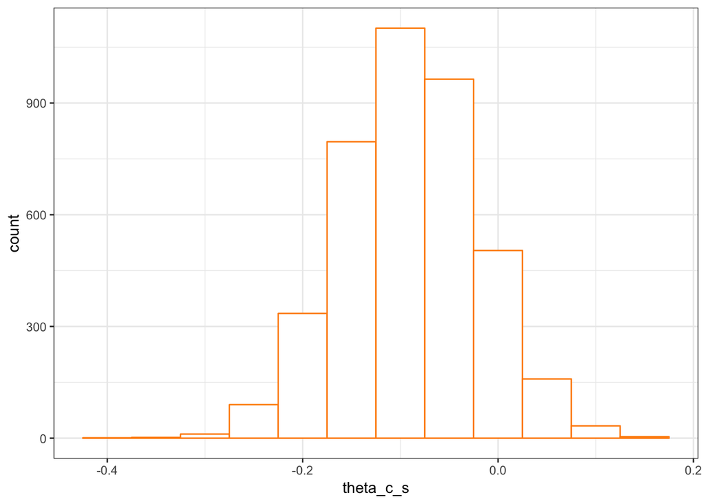

```r
reamostragens %>%
  ggplot(aes(x = theta_c_s)) +
  geom_histogram(binwidth = .05,
                 colour = "darkorange",
                 fill = "white")
```

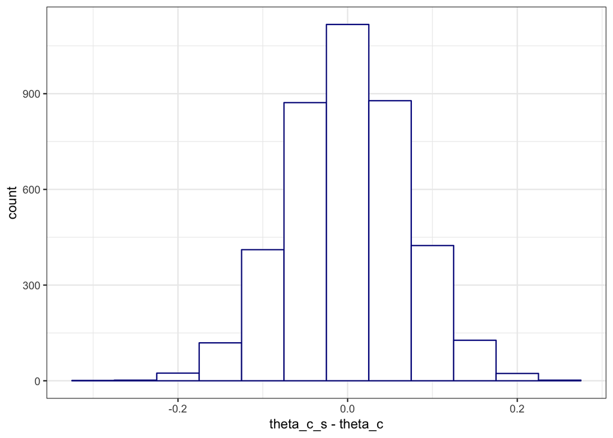

```r
reamostragens %>%
  ggplot(aes(x = theta_c_s - theta_c)) +
  geom_histogram(binwidth = .05,
                 colour = "darkblue",
                 fill = "white")
```

```r
intervalo = reamostragens %>%
  mutate(erro = theta_c_s - theta_c) %>%
  summarise(erro_i = quantile(erro, .025),
            erro_s = quantile(erro, .975))

intervalo
```

| erro_i | erro_s |
| --- | --- |
| -0.1355668 | 0.1348722 |

```r
intervalo = intervalo %>%
  mutate(valor_i = theta_c + erro_i,
         valor_s = theta_c + erro_s)

intervalo
```

| erro_i | erro_s | valor_i | valor_s |
| --- | --- | --- | --- |
| -0.1355668 | 0.1348722 | -0.2261753 | 0.04426369 |

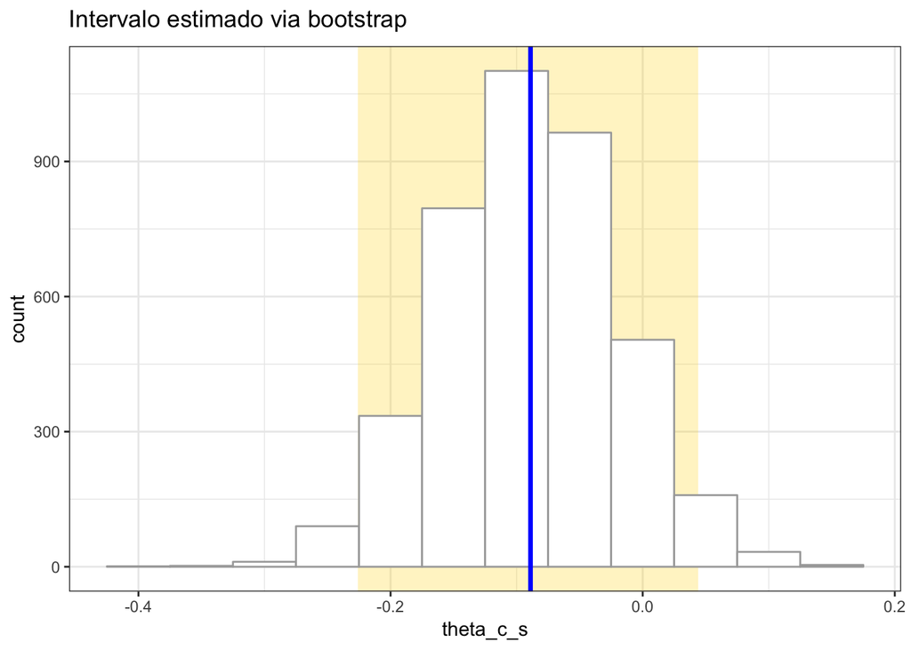

```r
ggplot() +
  geom_rect(
    data = intervalo,
    aes(xmin = valor_i, xmax = valor_s),
    ymin = -Inf,
    ymax = Inf,
    fill = "gold",
    alpha = .25
  ) +
  geom_histogram(
    data = reamostragens,
    aes(theta_c_s),
    binwidth = .05,
    fill = "white",
    colour = "darkgrey"
  ) +
  geom_vline(xintercept = theta,
             color = "blue",
             size = 1.2) +
  labs(title = expression("Intervalo estimado via bootstrap"))
```

# 2.1 - Correlação entre a popularidade mediana dos artistas escutado e a proporção dos artistas escutados que eram novos (Bootstrap Library).

```r
library(boot)

theta = function(df, i) {

    boot_df <- sample_n(df,
                        NROW(df),
                        replace = TRUE)
    pearson = pull(boot_df %>%
        slice(i) %>%
        summarise(pearson = cor(x = mediana_pop, y = news_prop_artist, method = "pearson")))

    return(pearson)
}

booted <- boot(data = mylastfm,
               statistic = theta,
               R = 2000)


ci = tidy(booted,
          conf.level = .95,
          conf.method = "bca",
          conf.int = TRUE)

glimpse(ci)
```

```
## Observations: 1
## Variables: 5
## $ statistic <dbl> -0.05331435
## $ bias      <dbl> 0.003729698
## $ std.error <dbl> 0.09517442
## $ conf.low  <dbl> -0.2426981
## $ conf.high <dbl> 0.1209429
```

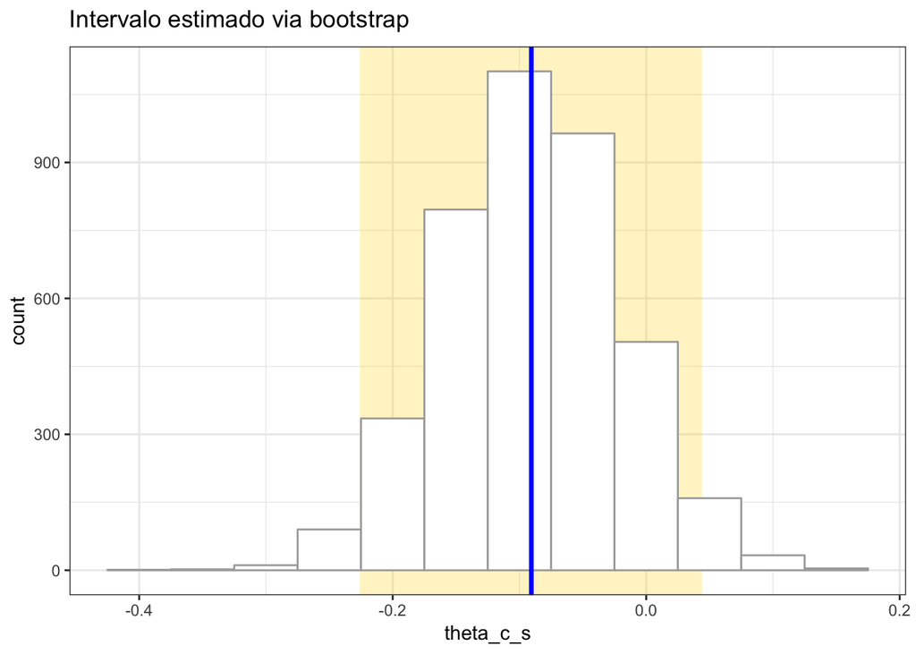

```r
ggplot() +
  geom_rect(
    data = intervalo,
    aes(xmin = valor_i, xmax = valor_s),
    ymin = -Inf,
    ymax = Inf,
    fill = "gold",
    alpha = .25
  ) +
  geom_histogram(
    data = reamostragens,
    aes(theta_c_s),
    binwidth = .05,
    fill = "white",
    colour = "darkgrey"
  ) +
  geom_vline(xintercept = theta_c,
             color = "blue",
             size = 1.2) +
labs(title = expression("Intervalo estimado via bootstrap"))
```

# 2.2 - Conclusões.

A correlação entre a popularidade mediana dos artistas escutado e a proporção dos artistas novos escutados esteve no intervalo de -0.22 a 0.04, com 95% de confiança. Com esses valores não é possível afirmar, com confiança, que a correlação seja negativa. Podemos afirmar que a mesma é minimamente fraca, visto que os valores não estão próximos de -1 ou 1. Além disso a correlação das reamostragens, condiz com a média da população como um todo.